# SimplyAgree: An R package and jamovi Module for Simplifying Agreement and Reliability Analyses

# Summary

Accurate and reliable measurements are critical to quantitative research efforts. Based on citation counts, researchers highly value methods to quantify the accuracy and reliability of the measurement tools (Bland & Altman, 1986; Weir, 2005). This article introduces the `SimplyAgree` R package and jamovi module as user-friendly solutions to estimating agreement and reliability (R Core Team, 2020; The jamovi project, 2021).

# Statement of Need

A number of new methods have been developed in the past three decades to improve the calculation of the limits of agreement (Lin, 1989; Shieh, 2019; Zou, 2011) and other measures of measurement reliability (Carrasco, Phillips, Puig-Martinez, King, & Chinchilli, 2013; Weir, 2005). However, to author’s best knowledge, statistical software — particularly open source software — to implement these tools is lacking. While some software may provide the agreement analysis outlined by Bland & Altman (1986, 1999), few, if any, account account for multiple observations within the same research subject (Zou, 2011) or include hypothesis tests of agreement (Shieh, 2019). Many researchers may not have the skills necessary to write statistical programming code in order to implement many of the newest techniques. The jamovi project (2021) is a open source statistical platform that provides a graphical user interface (GUI), and therefore is an accessible source for researchers without coding experience. Therefore, a jamovi module of `SimplyAgree` was also created in order to reach those researchers who may not have the coding expertise required to effectively use the R package.

# Current R Capabilities

The R package `SimplyAgree`, currently v0.0.2 on the comprehensive R archive network (CRAN), implements a number of useful agreement and reliability analyses that may be useful for researchers to evaluate their quantitative measurements.

The current release of the R package can be downloaded directly from CRAN in R:

```
install.packages("SimplyAgree")
```

Or, the developmental version, can be downloaded from GitHub:

```
devtools::install_github("arcaldwell49/SimplyAgree")
```

There are 2 vignettes that document the major functions within the package that can be found on the package’s website (https://aaroncaldwell.us/SimplyAgree). Overall, there are 6 fundamental functions within the R package:

1. `agree_test`: Simple Test of Agreement. This is function performs agreement analyses on two vectors of the same length, and is designed for analyses that were described by Bland & Altman (1986, 1999). In addition to providing the traditional Bland-Altman limits of agreement, the function provides a hypothesis test (Shieh, 2019), and provides the concordance correlation coefficient (Lin, 1989).
2. `agree_reps`: Test of Agreement for Replicate Data. This function provides the limits of agreement described by Zou (2011) for data where the mean, per subject, does not vary. In addition, the concordance correlation coefficient, calculated by U-statistics, is also provided in the output (Carrasco et al., 2013).
3. `agree_nest`: Test of Agreement for Nested Data.
4. `loa_mixed`: Bootstrapped Limits of Agreement.
5. `blandPowerCurve`: Power Analysis for Bland-Altman Limits of Agreement.
6. `reli_stats`: Reliability Statistics.

# Current jamovi Capabilities

The jamovi module can be added to the jamovi directly from the “add module” tab in the GUI.

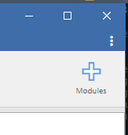

**Figure 1**: How to add a module in jamovi.

The `SimplyAgree` module is then available on the main menu, and within it there are three analysis options.

[figure not shown]

**Figure 2**: SimplyAgree in jamovi.

The three analysis options essentially enable jamovi users to complete some of the same analyses available in the R package.

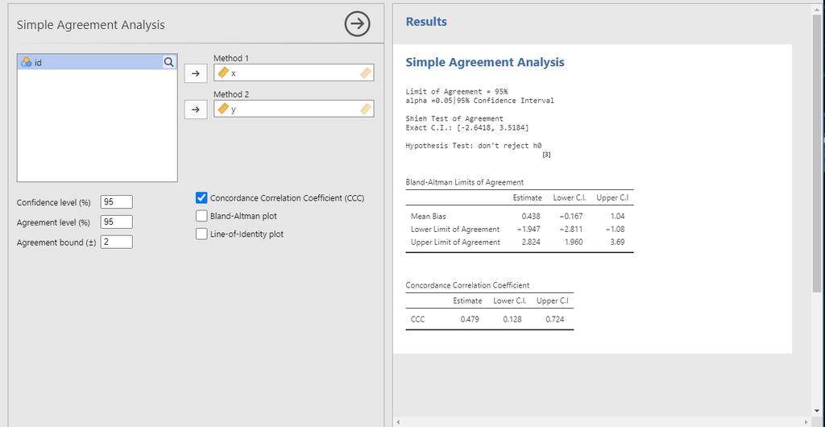

**Figure 3**: Sample Output from the Simple Agreement Analysis.

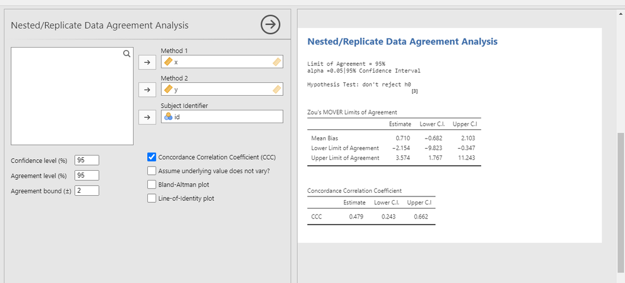

**Figure 4**:Sample Output from the Nested/Replicate Agreement Analysis.

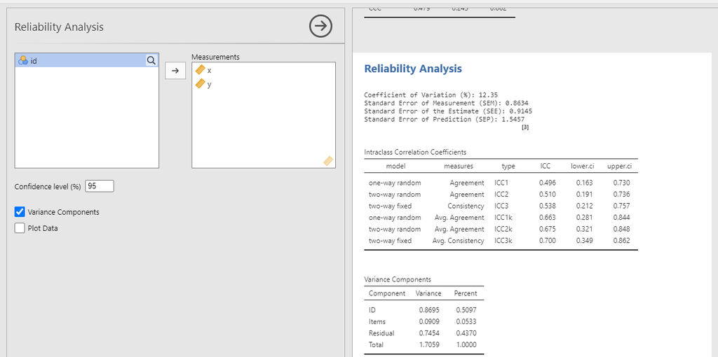

**Figure 5**: Sample Output from the Reliability Analsyis.

# Acknowledgements

I would like the thank Ashley Akerman for his kind feedback during the development of this package.

The opinions or assertions contained herein are the private views of the author and are not to be construed as official or reflecting the views of the Army or the Department of Defense. Any citations of commercial organizations and trade names in this report do not constitute an official Department of the Army endorsement of approval of the products or services of these organizations. No authors have any conflicts of interest to disclose. Approved for public release; distribution is unlimited.

# References

Bland, J. M., & Altman, D. (1986). Statistical methods for assessing agreement between two methods of clinical measurement. *The Lancet*, *327*(8476), 307–310. doi:10.1016/s0140-6736(86)90837-8

Bland, J. M., & Altman, D. G. (1999). Measuring agreement in method comparison studies. *Statistical Methods in Medical Research*, *8*(2), 135–160. doi:10.1177/096228029900800204

Carrasco, J. L., Phillips, B. R., Puig-Martinez, J., King, T. S., & Chinchilli, V. M. (2013). Estimation of the concordance correlation coefficient for repeated measures using SAS and r. *Computer Methods and Programs in Biomedicine*, *109*(3), 293–304. doi:10.1016/j.cmpb.2012.09.002

Lin, L. I.-K. (1989). A concordance correlation coefficient to evaluate reproducibility. *Biometrics*, *45*(1), 255. doi:10.2307/2532051

R Core Team. (2020). *R: A language and environment for statistical computing*. Vienna, Austria: R Foundation for Statistical Computing. Retrieved from https://www.R-project.org/

Shieh, G. (2019). Assessing agreement between two methods of quantitative measurements: Exact test procedure and sample size calculation. *Statistics in Biopharmaceutical Research*, *12*(3), 352–359. doi:10.1080/19466315.2019.1677495

The jamovi project. (2021). *Jamovi*. Retrieved from https://www.jamovi.org

Weir, J. P. (2005). Quantifying test-retest reliability using the intraclass correlation coefficient and the SEM. *The Journal of Strength and Conditioning Research*, *19*(1), 231. Retrieved from https://pubmed.ncbi.nlm.nih.gov/15705040/

Zou, G. (2011). Confidence interval estimation for the blandAltman limits of agreement with multiple observations per individual. *Statistical Methods in Medical Research*, *22*(6), 630–642. doi:10.1177/0962280211402548